# Association between genomic/clinical data and drug response (Fig 4 + SuppFig 5)

# analysis

preprocessing [R] -> training and CV model [python] -> evaluating models [R - not replicable with github] -> plots - python code “src/analysis/3.catboost_py.ipynb” - saved trained models can be found in “output/rds/cv_results_all170.pkl”

# association between features and drug response

```r
sampleinfo_full <- read.csv("data/oshu/clinical_summary.csv") [1:596,]

sampleinfo <- read.csv("data/oshu/sampleinfo_dss.csv")[1:596,]

cells <- data.frame(sampleinfo_full[,c(54, 56:57,59:61,63:69,71)], row.names = sampleinfo_full$Sample_ID)
log_vars <- c("ALT", "AST", "creatinine", "wbcCount", "plateletCount") # usually right skewed
log_vars <- c(log_vars, "percentBasophilsPB", "percentEosinophilsPB") # rare population and right skewed with high outliers clinical relevance often lies in fold-change or elevation
cells[log_vars] <- log1p(cells[log_vars])

prior <- data.frame(sampleinfo[c(23,24,26,28)], row.names = sampleinfo$Sample_ID)

mutation <- data.frame(sampleinfo[,c(32:55,58:103)], row.names = sampleinfo$Sample_ID)
mutation <- mutation[,colSums(mutation, na.rm = T) >= 10] # removed columns with < 10 non positive

cyto <- read.csv("data/oshu/clinical_cyto.csv", check.names = F)[1:596,]
rownames(cyto) <- cyto$Sample_ID
cyto <- cyto[sampleinfo$Sample_ID ,6:17]
cyto <- cyto[,colSums(cyto, na.rm = T) >= 10]

immuno <- read.csv("data/oshu/clinical_immuno.csv")[1:596,]
immuno <- data.frame(immuno[,4:ncol(immuno)], row.names = immuno$Sample_ID) %>%
  mutate_all(.funs = ~ ifelse(.x=="-", F, ifelse(is.na(.x), NA, T)) )
immuno <- immuno[,colSums(immuno, na.rm = T) >= 10] # removed columns with < 10 non positive
```

```r
## risk, FAB and diagnosis, age, gender
# unknown is removed
df_all <- data.frame(Age = sampleinfo$Age,
                     timepoint = sampleinfo_full$timeOfSampleCollectionRelativeToInclusion,
                     FAB_subtype = sampleinfo$FAB_subtype,
                     ELN2022 = sampleinfo$ELN2022,
                     Gender = sampleinfo_full$gender,
                     DvsT = sampleinfo$Disease.status,
                     row.names = sampleinfo$Sample_ID) %>%
  mutate(
    FAB_subtype = ifelse(FAB_subtype=="M0/M1", "M0", FAB_subtype),
    DvsT = case_when(DvsT %in% c("Relapse","Residual") ~ "RR", .default = DvsT),
    isMale = ifelse(Gender=="Male", TRUE, ifelse(Gender=="Female", FALSE, NA))
    ) %>%
  mutate(
    FAB_subtype = factor(FAB_subtype, levels = c("M0", "M1", "M2", "M3", "M4", "M5", "M7")),
    DvsT = factor(DvsT, levels=c("Diagnosis", "RR", "Remission", "Unknown"), ordered = F)
    ) %>%
  select(-Gender)
```

## saving putting all in the same df; exporting to run in python

```r
X_all_categorical <- bind_cols(df_all[3:ncol(df_all)], prior, mutation, immuno, cyto) # 86

X_all_numerical <- bind_cols(cells, df_all[1])# 15

X_all <- cbind(X_all_numerical, X_all_categorical) # 101

combi.m <- data.frame(sampleinfo[,155:324], row.names = sampleinfo$Sample_ID)
combi.m <- combi.m[,colSums(!is.na(combi.m), na.rm = T) >= 20] # range (23-523)
Y_all <- combi.m # 170

df <- cbind(sampleinfo_full[c("Sample_ID", "patientId")], X_all, Y_all)

# df %>% write.csv("output/supp/ML/preprocessed_df.csv", row.names = F)
```

## verifying if the features are informative

### checking with features

```r
#### categorical
colSums(!is.na(prior))
```

```
priorMalignancyRadiationTx                   priorMDS                priorMDSMPN
                       596                        596                        596
                  priorMPN
                       596
```

```r
colSums(!is.na(cyto))
```

```
   CBFB-MYH11      KMT2A_re      MECOM_re      PML-RARA RUNX1-RUNX1T1      Other_re
          541           539           538           538           538           538
    Other_abn    Other_abn2
          538           538
```

```r
colSums(!is.na(mutation))
```

```
 ASXL1  ATG2B    ATM   BCOR BCORL1    CBL  CEBPA CREBBP  CSF3R DNMT3A   EZH2   FAT4
   533    533    533    533    533    533    533    533    533    533    533    533
  FLT3  GATA2   IDH1   IDH2  IKZF1   JAK2    KIT  KMT2A  KMT2D   KRAS    MLL    NF1
   560    533    533    533    533    533    533    533    533    533    533    533
NOTCH1   NPM1   NRAS   PHF6 PTPN11  RAD21  RUNX1 SETBP1  SF3B1  SMC1A  SRSF2  STAG2
   533    554    533    533    533    533    533    533    533    533    533    533
  TET2   TP53  U2AF1  USH2A    WT1  ZRSR2
   533    533    533    533    533    533
```

```r
colSums(!is.na(immuno))
```

```
   CD2    CD4    CD7    CD9   CD10  CD11b  CD11c   CD13   CD14   CD15   CD16   CD19
   416    416    416    416    416    416    416    416    416    416    416    416
  CD22   CD25   CD33   CD34   CD38   CD45   CD56   CD58   CD64   CD71  CD79a  CD117
   416    416    416    416    416    416    416    416    416    416    416    416
 CD123 HLA.DR    TdT    MPO
   416    416    416    416
```

```r
colSums(!is.na(df_all))
```

```
        Age   timepoint FAB_subtype     ELN2022        DvsT      isMale
        563         596         354         596         596         585
```

```r
colSums(prior, na.rm = T)
```

```
priorMalignancyRadiationTx                   priorMDS                priorMDSMPN
                        10                         44                         26
                  priorMPN
                        26
```

```r
colSums(cyto, na.rm = T)
```

```
   CBFB-MYH11      KMT2A_re      MECOM_re      PML-RARA RUNX1-RUNX1T1      Other_re
           35            37            16            10            10            95
    Other_abn    Other_abn2
          155           168
```

```r
colSums(mutation, na.rm = T)
```

```
 ASXL1  ATG2B    ATM   BCOR BCORL1    CBL  CEBPA CREBBP  CSF3R DNMT3A   EZH2   FAT4
    76     12     11     32     13     26     52     17     13    130     21     10
  FLT3  GATA2   IDH1   IDH2  IKZF1   JAK2    KIT  KMT2A  KMT2D   KRAS    MLL    NF1
   219     43     47     63     11     29     23     18     15     34     15     25
NOTCH1   NPM1   NRAS   PHF6 PTPN11  RAD21  RUNX1 SETBP1  SF3B1  SMC1A  SRSF2  STAG2
    12    169    108     19     38     14     92     12     44     13     70     37
  TET2   TP53  U2AF1  USH2A    WT1  ZRSR2
    99     39     22     10     49     13
```

```r
colSums(immuno, na.rm = T)
```

```
   CD2    CD4    CD7    CD9   CD10  CD11b  CD11c   CD13   CD14   CD15   CD16   CD19
    16     77    111     40     13    157     24    348     86     93     29     13
  CD22   CD25   CD33   CD34   CD38   CD45   CD56   CD58   CD64   CD71  CD79a  CD117
    10     16    367    277    257     65    112     90    172     26     15    338
 CD123 HLA.DR    TdT    MPO
   136    316     44    222
```

```r
# colSums(df_all, na.rm = T)

#### numerical
colSums(!is.na(cells))
```

```
     percentBlastsBM   percentBasophilsPB percentEosinophilsPB percentLymphocytesPB
                 423                  363                  386                  398
  percentMonocytesPB percentNeutrophilsPB             wbcCount        plateletCount
                 398                  395                  482                  448
             albumin           creatinine           hemoglobin                  ALT
                 373                  356                  416                  375
                 AST                  MCV
                 375                  372
```

```r
quantile(colSums(!is.na(combi.m)))
```

```
    0%    25%    50%    75%   100%
 23.00  34.00  91.00 220.25 523.00
```

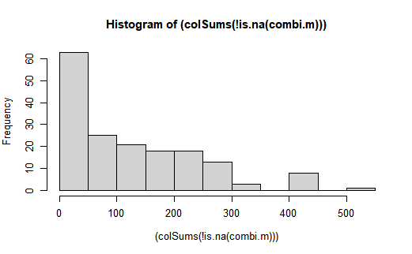

```r
hist((colSums(!is.na(combi.m))))
```

### helper function

- categorical
  - missing_rate: proportion of NA values ( < 0.5)
  - entropy: diversity of categories ( > 0.5)
  - n_levels: number of unique categories
  - dominant_prop: proportion of the most frequent category ( < 0.95)
- numerical
  - Missing rate: How much data is missing ( < 0.5)
  - Skewness: Whether the distribution is symmetric or distorted ( < +-2)
  - Outlier proportion: How many values lie far outside the typical range ( < 0.05)
  - Spread: A proxy for entropy—features with very narrow range may be uninformative (not low)

```r
# missing_rate: proportion of NA values
# entropy: diversity of categories
# n_levels: number of unique categories
# dominant_prop: proportion of the most frequent category
score_categorical_features <- function(df, threshold_missing = 0.5, threshold_entropy = 0.5, threshold_dominant_prop = 0.95) {

  # Helper: Shannon's entropy function
  calc_entropy <- function(x) {
    freq <- table(x) / length(x)
    -sum(freq * log2(freq + 1e-9))  # add small value to avoid log(0)
  }

  # Identify categorical columns (factor or character)
  cat_cols <- names(df)[sapply(df, function(col) is.logical(col) || is.factor(col) || is.character(col))]

  # Score each categorical feature
  scores <- lapply(cat_cols, function(col_name) {
    col <- df[[col_name]]
    missing_rate <- mean(is.na(col))
    entropy <- calc_entropy(col[!is.na(col)])
    n_levels <- length(unique(col[!is.na(col)]))
    dominant_prop <- max(table(col[!is.na(col)]) / length(col[!is.na(col)]))

    data.frame(
      feature = col_name,
      missing_rate = missing_rate,
      entropy = entropy,
      n_levels = n_levels,
      dominant_prop = dominant_prop,
      keep = (missing_rate < threshold_missing) & (entropy > threshold_entropy) & (dominant_prop < threshold_dominant_prop)
    )
  }) %>% bind_rows()

  return(scores)
}

# Missing rate: How much data is missing
# Skewness: Whether the distribution is symmetric or distorted
# Outlier proportion: How many values lie far outside the typical range
# Spread: A proxy for entropy—features with very narrow range may be uninformative
score_numerical_features <- function(df, threshold_missing = 0.5, threshold_skew = 2, threshold_outlier_prop = 0.05) {
  library(dplyr)

  # Identify numeric columns
  num_cols <- names(df)[sapply(df, is.numeric)]

  # Score each numeric feature
  scores <- lapply(num_cols, function(col_name) {
    col <- df[[col_name]]
    col_clean <- col[!is.na(col)]

    missing_rate <- mean(is.na(col))
    skewness <- e1071::skewness(col_clean)

    # Outlier detection using 1.5 * IQR rule
    qnt <- quantile(col_clean, probs = c(0.25, 0.75))
    iqr <- IQR(col_clean)
    lower <- qnt[1] - 1.5 * iqr
    upper <- qnt[2] + 1.5 * iqr
    outlier_prop <- mean(col_clean < lower | col_clean > upper)

    # Spread proxy: log of range
    spread <- log1p(max(col_clean) - min(col_clean))

    keep <- (missing_rate < threshold_missing) &
            (abs(skewness) < threshold_skew) &
            (outlier_prop < threshold_outlier_prop)

    data.frame(
      feature = col_name,
      missing_rate = missing_rate,
      skewness = skewness,
      outlier_prop = outlier_prop,
      spread = spread,
      keep = keep
    )
  }) %>% bind_rows()

  return(scores)
}
```

```r
score_categorical_features(X_all_categorical) %>% DT::datatable()
```

|  | feature | missing_rate | entropy | n_levels | dominant_prop | keep |
| --- | --- | --- | --- | --- | --- | --- |
| 1 | FAB_subtype | 0.4060402684563759 | 2.422201497967643 | 7 | 0.2344632768361582 | True |
| 2 | ELN2022 | 0 | 2.024868894578328 | 5 | 0.3523489932885906 | True |
| 3 | DvsT | 0 | 1.273513215255995 | 4 | 0.6476510067114094 | True |
| 4 | isMale | 0.01845637583892618 | 0.9874664148446601 | 2 | 0.5658119658119658 | True |
| 5 | priorMalignancyRadiationTx | 0 | 0.1229490584487332 | 2 | 0.9832214765100671 | False |
| 6 | priorMDS | 0 | 0.3800401763660494 | 2 | 0.9261744966442953 | False |
| 7 | priorMDSMPN | 0 | 0.2586689289335372 | 2 | 0.9563758389261745 | False |
| 8 | priorMPN | 0 | 0.2586689289335372 | 2 | 0.9563758389261745 | False |
| 9 | ASXL1 | 0.1057046979865772 | 0.5909795185918902 | 2 | 0.8574108818011257 | True |
| 10 | ATG2B | 0.1057046979865772 | 0.1553326918142048 | 2 | 0.9774859287054409 | False |

[output cut: 76 more lines]

```r
score_numerical_features(X_all_numerical) %>% DT::datatable()
```

|  | feature | missing_rate | skewness | outlier_prop | spread | keep |
| --- | --- | --- | --- | --- | --- | --- |
| 1 | percentBlastsBM | 0.2902684563758389 | -0.727118432173319 | 0 | 4.590056548178043 | True |
| 2 | percentBasophilsPB | 0.3909395973154363 | 2.452095391311468 | 0.2258953168044077 | 1.455042034476351 | False |
| 3 | percentEosinophilsPB | 0.3523489932885906 | 1.84198187958549 | 0.04404145077720207 | 1.588396817747323 | True |
| 4 | percentLymphocytesPB | 0.3322147651006712 | 1.604180869316161 | 0.05527638190954774 | 4.49647076906475 | False |
| 5 | percentMonocytesPB | 0.3322147651006712 | 1.671968415329621 | 0.1030150753768844 | 4.541164856012179 | False |
| 6 | percentNeutrophilsPB | 0.337248322147651 | 1.593557559538199 | 0.07341772151898734 | 4.454347296253507 | False |
| 7 | wbcCount | 0.1912751677852349 | -0.2722434532566567 | 0 | 1.895328222139435 | True |
| 8 | plateletCount | 0.2483221476510067 | 0.2995048604152983 | 0.01339285714285714 | 1.964025119403345 | True |
| 9 | albumin | 0.3741610738255033 | 0.1097701901447256 | 0.002680965147453083 | 1.435084525289323 | True |
| 10 | creatinine | 0.4026845637583892 | 2.079887698498107 | 0.03932584269662921 | 1.048892668735201 | False |

[output cut: 5 more lines]

# running catboost + shap in python

- refer to src/analysis/3.catboost_py.ipynb
- SHAP values are in the same units as the model output (e.g., DSS score)
  - global SHAP values for continuous variables and categorical variables should be looked at separately
  - comparing Global SHAP (e.g., mean absolute SHAP per feature) summarizes importance across the dataset
- running with default model
  - 170 combinations
  - 101 features - 15 numerical, 86 categorical
  - using grouped 5-fold CV
  - evaluate the performance of the model R^2 or RMSE to ensure that there isnt overfitting/underfitting -> affects the reliability of the SHAP values
- advantage
  - native handling of categorical features && missingness && its default model is quite balanced in bias-variance (but non-random missingness still affects); stability with small datasets
- to consider
  - not well tuned models (over/underfitting); black box
  - doesnt capture interactions fully
  - small sample size / no test set/ noise causing overestimating generalizability
  - cross drug/model compatibility
- what is exported
  - per combination
    - fold-wise shap values on test sets
    - stability metrics of each feature
    - sample level + fold-wise residuals (obs.val - pred.val)
    - sample level + fold-wise shap values

# [not included in github] evaluation

- obtain raw files by running the saved python models
  - “_shap_foldwise.csv”; “_residuals.csv”

```r
base.dir = "output/supp/ML/diagnostics/"
listofcombi <- read.csv("data/oshu/combi_detail.csv")[,c(1,2,4,5)] %>% unique() %>%
  mutate(changedname = gsub("[ -]", ".", combo))

topcombi <- read.csv("output/oshu_combinationindex.csv") %>%
  mutate(combo = Combination,
         Combination = gsub("[ -]", ".", Combination))

r_squared <- function(y_val, y_pred) {
  ss_res <- sum((y_val - y_pred)^2)
  ss_tot <- sum((y_val - mean(y_val))^2)
  1 - (ss_res / ss_tot)
}

df <- read.csv("output/supp/ML/preprocessed_df.csv", check.names = F) %>%
  rename(DiseaseStatus = DvsT)
X_all <- df[3:103]
categories <- data.frame(feature = colnames(X_all),
                         type = c(rep("numeric", 15), rep("category", 86)))
```

## tbl8: model evaluation

- diagnosing the cause of instability
  - small sample size
  - missingness of information / noise/ outlier
  - poor signals - lack of strong signal from a single feature
  - the target is just all max/min out
- filtering out unstable models
  - kendall tau - directly compares pairs of data points to see if they are concordant (spearman reports pearson’s of the ranks)
    - important to also eval the p values - such that the coef isnt just randomness
    - using 1-sided test “greater” to only look for positive corr; rsq > 0 to ensure that its better than mean
- stability determined by the no. of positive and signif tau values
  - poor: 0-1: model is unable to consistently find a signal in the data that generalizes across different subsets.
  - unstable: 2-3: tentative but inconsistent signal
  - stable: 4-5

```r
rawfiles = list.files(path = base.dir, pattern = ".*_residuals.csv")
rawfiles_name <- gsub("_residuals.csv", "", rawfiles)

df_list <- lapply(rawfiles, function(i) read.csv(paste0(base.dir, i)))
names(df_list) <- rawfiles_name

perf_summary_df <- rbindlist(df_list, idcol = "changedname")

perf_summary_perfold <- perf_summary_df %>%
  group_by(changedname, fold) %>%
  summarise(
    PearsonR = round(cor(y_true, y_pred), 5),
    PearsonP = signif(cor.test(y_true, y_pred, method = "pearson")$p.value, 5),
    KendallT = round(cor(y_true, y_pred, method = "kendall"), 5),
    KendallP = signif(cor.test(y_true, y_pred, method = "kendall", exact = T, continuity = T, alternative = "greater")$p.value, 5),
    rsq = round(r_squared(y_true, y_pred), 5),
    n_samples_perfold = n()) %>% ungroup() %>%
  mutate(sig_kendall = KendallP < 0.05 & rsq > 0) %>%
  group_by(changedname) %>%
  mutate(
    n_samples = sum(n_samples_perfold),
    n_sig_fold = sum(sig_kendall),
    category = case_when(
      n_sig_fold >= 4 ~ "stable",
      n_sig_fold >= 2 ~ "unstable",
      .default = "poor"
      )
    ) %>% ungroup()  %>%
  left_join(topcombi[,c(1,5,11,12)], by=c("changedname" = "Combination")) %>%
  dplyr::select(Combination := last_col(), everything()) %>% dplyr::select(-2)

## table 8
write.csv(perf_summary_perfold, "output/model_perf_summary_perfold.csv", row.names = F)

perf_summary <- perf_summary_perfold %>%
  select(Combination, n_samples, n_sig_fold, category, median_CR, Better_combi) %>%
  distinct_all()

table(perf_summary$category)
cut(perf_summary$n_samples, breaks = seq(0, 530, by=25), include.lowest = TRUE) %>% table(., perf_summary$category)

write.csv(perf_summary, "output/supp/ML/model_perf_summary_df.csv", row.names = F)
```

## feature stability (gathering SHAP values)

- Using SHAP values from the test folds of a 5-fold CV is a statistically sound and biologically compelling method for your goal. This is a powerful, defensible, and rigorous approach that directly addresses the core question of robustness.
- entropy < 1.5
  - Entropy ranges from 0 (perfectly stable rank) to log(N) where N is number of ranks (e.g. log₂(5) ≈ 2.32 for 5 folds).
- cv < 0.5
  - = SD / mean of absolute SHAP values (changing SD to R’s instead of np.std)
  - implies that the SHAP values vary less than half their mean—reasonable for biological interpretation.
- high mean + low sd == low CV

```r
rawfiles = list.files(path = base.dir, pattern = ".*_feature_stability.csv")
rawfiles_name <- gsub("_feature_stability.csv", "", rawfiles)

df_list <- lapply(rawfiles, function(i) read.csv(paste0(base.dir, i)))
names(df_list) <- rawfiles_name

rawfiles_1 = list.files(path = base.dir, pattern = ".*_shap_foldwise.csv")

feature_summary_df <- rbindlist(df_list, idcol = "changedname") %>%
  mutate(feature = ifelse(feature == "DvsT", "DiseaseStatus", feature))

feature_summary_df <- feature_summary_df %>%
  left_join(topcombi[,c(1,12)], by=c("changedname" = "Combination")) %>%
  dplyr::select(Combination := last_col(), everything()) %>% dplyr::select(-2) %>%
  left_join(categories) %>%
  group_by(Combination, type) %>%
  mutate(rank = rank(-mean_abs_shap, ties.method = "average"),
         rank = case_when(mean_abs_shap == 0 & type == "numeric" ~ 15,
                          mean_abs_shap == 0 & type == "category" ~ 86,
                          .default = rank) # when feature has no contribution
         )

write.csv(feature_summary_df, "output/supp/ML/feature_summary_df.csv", row.names = F)
```

## feature stability of reliable folds and models only

- only considering (poor models are not included)
  - all folds of stable models
  - sig folds of unstable models

```r
na_mask <- perf_summary_perfold %>%
  mutate(fold = paste0("fold", fold) ) %>%
  dplyr::select(Combination, fold, sig_kendall, n_samples, n_sig_fold, category, median_CR, Better_combi) %>%
  filter(category != "poor")

x <- feature_summary_df[,c(1,2,7:11, 17)] %>% ungroup() %>%
  pivot_longer(cols = starts_with("fold"), names_to = "fold", values_to = "mean_abs_shap") %>%
  mutate(fold = gsub("_mean_abs_shap", "", fold)) %>%
  inner_join(na_mask)

## keeping only sig folds
unstable_feature_sum <- x %>% filter(category == "unstable", sig_kendall == T) %>%
  group_by(Combination, feature, category, median_CR, Better_combi, n_sig_fold, n_samples, type) %>%
  summarise(mean_abs_shap = mean(mean_abs_shap))  %>%
  ungroup() %>%
  group_by(Combination, type) %>%
  mutate(rank = rank(-mean_abs_shap, ties.method = "average"),
         rank = case_when(mean_abs_shap == 0 & type == "numeric" ~ 15,
                          mean_abs_shap == 0 & type == "category" ~ 86,
                          .default = rank) # when feature has no contribution
         )
write.csv(unstable_feature_sum, "output/supp/ML/unstable_feature_summary_df.csv", row.names = F)

## using all folds for robustness
stable_feature_sum <- x %>% filter(category == "stable") %>%
  group_by(Combination, feature, category, median_CR, Better_combi, n_sig_fold, n_samples, type) %>%
  summarise(mean_abs_shap = mean(mean_abs_shap))  %>%
  ungroup() %>%
  group_by(Combination, type) %>%
  mutate(rank = rank(-mean_abs_shap, ties.method = "average"),
         rank = case_when(mean_abs_shap == 0 & type == "numeric" ~ 15,
                          mean_abs_shap == 0 & type == "category" ~ 86,
                          .default = rank) # when feature has no contribution
         )
write.csv(stable_feature_sum, "output/supp/ML/stable_feature_summary_df.csv", row.names = F)
```

## tbl 9: saving all summary

- saving per feature per model averaged across selected folds
- saving poor models at the bottom

```r
perf_summary <- read.csv("output/supp/ML/model_perf_summary_df.csv") %>% filter(category =="poor")
stable_feature_sum <- read.csv("output/supp/ML/stable_feature_summary_df.csv")
unstable_feature_sum <- read.csv("output/supp/ML/unstable_feature_summary_df.csv")
df <- rbind(stable_feature_sum, unstable_feature_sum) %>%
  arrange(category, Combination, rank) %>%
  bind_rows(perf_summary)

write.csv(df, "output/all_feature_summary_df.csv", row.names = F)
```

## tbl 10b: shap vs feature value (SHAP value - contribution of each features at sample level)

- for beeswarm plot
- combining
  - for each combination
  - for each sample
  - for each feature
    - test shap value
    - feature value
    - observed DSS

```r
## shap per sample
rawfiles = list.files(path = base.dir, pattern = ".*_shap_stacked_sample_by_feature.csv")
rawfiles_name <- gsub("_shap_stacked_sample_by_feature.csv", "", rawfiles)

df_list <- lapply(rawfiles, function(i) read.csv(paste0(base.dir, i), check.names = F))
names(df_list) <- rawfiles_name

shap_per_sample_df <- rbindlist(df_list, idcol = "changedname") %>%
  rename(DiseaseStatus = DvsT)

## outputs per sample
rawfiles = list.files(path = base.dir, pattern = ".*_residuals.csv")
rawfiles_name <- gsub("_residuals.csv", "", rawfiles)

df_list <- lapply(rawfiles, function(i) read.csv(paste0(base.dir, i), check.names = F))
names(df_list) <- rawfiles_name

DSS_per_sample_df <- rbindlist(df_list, idcol = "changedname")

## combine
shap_summary_df <- bind_cols(DSS_per_sample_df, shap_per_sample_df[, 2:102]) %>%
  mutate(Combination = listofnames[changedname]) %>%
  select(Combination, everything())

write.csv(shap_summary_df, "output/shap_summary_df.csv", row.names = F)
```

# plot

```r
perf_summary <- read.csv("output/supp/ML/model_perf_summary_df.csv")
feature_summary_df <- read.csv("output/supp/ML/feature_summary_df.csv")
shap_summary_df <- read.csv("output/shap_summary_df.csv", check.names = F)

stable_feature_sum <- read.csv("output/supp/ML/stable_feature_summary_df.csv")
unstable_feature_sum <- read.csv("output/supp/ML/unstable_feature_summary_df.csv")

df <- read.csv("output/supp/ML/preprocessed_df.csv", check.names = F) %>%
  rename(DiseaseStatus = DvsT)
X_all <- df[3:103]
rownames(X_all) <- df$Sample_ID
Y_all <- df[104:273]
rownames(Y_all) <- df$Sample_ID

categories <- data.frame(feature = colnames(X_all),
                         type = c(rep("numeric", 15), rep("category", 86)))
```

## fig 4d: heatmap of stable + unstable shap (n=43)

```r
df <- rbind(stable_feature_sum, unstable_feature_sum)

## matrix of rank for heatmap
df_wide <- reshape2::acast(df, Combination ~ feature, value.var = "rank", fill = 0)

df_wide_cat <- df_wide[, categories$feature[categories$type == "category"] ]
df_wide_cat <- df_wide_cat[, order(colMedians(df_wide_cat), decreasing = F)]

df_wide_num <- df_wide[, categories$feature[categories$type == "numeric"] ]
df_wide_num <- df_wide_num[, order(colMedians(df_wide_num), decreasing = F)]

## split between unstable and stable
split <- distinct_all(df[,c(1,3)]) %>% column_to_rownames("Combination")
split <- split[rownames(df_wide),]
```

```r
col_fun1 <- colorRamp2(c(86, 10, 1), c("#f7fbff", "#6baed6", "#08306b"))
col_fun2 <- colorRamp2(c(15, 5, 1), c("#f7fcf5", "#74c476", "#00441b"))

## barplot annot
ha1 = HeatmapAnnotation(RankDistribtion = anno_boxplot(df_wide_cat, height = unit(3, "cm"), gp = gpar(fill = "#6baed6"), axis_param = list(side = "right", direction = "reverse")), annotation_name_rot = 0)
ha2 = HeatmapAnnotation(RankDistribtion = anno_boxplot(df_wide_num, height = unit(3, "cm"), gp = gpar(fill = "#74c476"), axis_param = list(direction = "reverse" )), show_annotation_name = F, annotation_name_rot = 0)

## heatemap
hm1 <- Heatmap(df_wide_cat, name = "Category SHAP Rank",
        rect_gp = gpar(col = "white", lwd=0.5),
        col = col_fun1, cluster_columns = F, #cluster_rows = F,
        clustering_distance_rows = "pearson",
        show_row_dend = F,
        bottom_annotation = ha1,
        column_title = "category",
        width = unit(0.15*ncol(df_wide_cat), "in"),
        height = unit(0.15*nrow(df_wide_cat), "in"),
        row_split = split
        # right_annotation = row_anno
        )

hm2 <- Heatmap(df_wide_num, name = "Numeric SHAP Rank",
        rect_gp = gpar(col = "white", lwd=0.5),
        col = col_fun2, cluster_columns = F, #cluster_rows = F,
        clustering_distance_rows = "pearson",
        show_row_dend = F,
        bottom_annotation = ha2,
        column_title = "numeric",
        width = unit(0.15*ncol(df_wide_num), "in"),
        height = unit(0.15*nrow(df_wide_num), "in"),
        row_split = split
        )

# png("plot/fig4/main_4d_hm_catboost.png", res=600, width = 0.15*ncol(df_wide) + 5, height = 0.15*nrow(df_wide) + 5, units = "in", family = "Arial", bg = "transparent")
Cairo::CairoPDF("plot/fig4/main_4d_hm_catboost.pdf",  width = 0.15*ncol(df_wide) + 5, height = 0.15*nrow(df_wide) + 5, bg = "transparent", family = "Arial")
draw(hm2 + hm1, heatmap_legend_side = "bottom", background = "transparent")
```

## tbl 10a & fig 4c: scatterplot across models

```r
df <- rbind(stable_feature_sum, unstable_feature_sum) %>%
  filter(mean_abs_shap != 0, # filtering out uninformative features
         ) %>%
  mutate(norm_rank = case_when(type == "numeric" ~ rank/15, type == "category" ~ rank/86)
         ) %>%
  group_by(feature, type) %>%
  reframe(mean_rank = mean(norm_rank),
          median_rank = median(norm_rank),
         sd_rank = sd(norm_rank),
         n_model = n()
         )
```

```r
annotating_features <- cbind(categories,
                             category = c(
                               rep("clinical labs", 14),
                               rep("patient info", 9),
                               rep("mutation", 42),
                               rep("IHC", 28),
                               rep("cytogenetics", 8)
                             )
                             )

df <- left_join(df, annotating_features)
write.csv(df, "output/top_feature_summary_df.csv", row.names = F)

p <- df %>%
  ggplot(., aes(x =mean_rank, y = sd_rank, label = feature, size = n_model, color = category, shape = type)) +
  geom_point(alpha = 0.7) +
  ggrepel::geom_text_repel(size = 3, max.overlaps = 17) +
  scale_color_manual(values = c("#377EB8", "#4DAF4A", "#E6AB02",  "#A65628", "#F781BF")) +
  # scale_size(range = c(1,8)) +
  scale_radius(range = c(0.1,3)) +
  geom_vline(xintercept = 0.5, lty=2) +
  scale_y_continuous(transform = "log10") +
  geom_hline(yintercept = 0.25, lty=2)  +
  theme_minimal(base_family = 14) +
  labs(#title = "SHAP Feature Rank Stability Across Models",
       x = "Mean Rank (lower = more important)",
       y = "Rank Standard Deviation (lower = more stable)") +
  theme(aspect.ratio = 1) +
  guides(color = guide_legend(override.aes = list(label="", size=3) ),
         shape = guide_legend(override.aes = list(size=3) )) +
  theme_pdf

ggsave(plot = p, "plot/fig4/main_4c_scatterplot_global_shap.png", width=6.5, height=5.5, dpi=600, bg = "transparent")
ggsave(plot = p, "plot/fig4/main_4c_scatterplot_global_shap.pdf", width=6.5, height=5.5, bg = "transparent", device = cairo_pdf)
```

## observation (using stable & unstable only)

```r
## to use both stable and unstable
perf_summary_perfold <- read.csv("output/model_perf_summary_perfold.csv")
keep_fold <- perf_summary_perfold %>% filter(category == "stable"|(category == "unstable" & sig_kendall == T))

all_feature_sum <- rbind(stable_feature_sum, unstable_feature_sum)
shap_summary_df_filt <- inner_join(shap_summary_df, keep_fold[1:2])

# write.csv(shap_summary_df_filt, "output/supp/ML/shap_summary_df_filt.csv", row.names = F)
```

### selected

```r
# setting defaults
color_category <- c(subtype.col3, eln.col[1:4], disease.col3,
                    "RR" = "firebrick",
                    "TRUE" = "#c5247d",
                    "FALSE" = "#4d9220")
# x_range = shap_values$shap_value %>% quantile(probs = c(0,1))
type = ""

color_setting <- if(type == "category"){
  scale_color_manual(values = color_category, name = "Category\nFeature values")} else {scale_color_distiller(palette = "PiYG", name = "Numeric\nFeature values")}

legend_setting <- if(type == "category"){
  theme(legend.key.height = unit(0.1,"cm"))} else {theme(legend.key.height = unit(0.3,"cm"))}

minmax_scale <- function(x) {
  (x - min(x, na.rm = TRUE)) / (max(x, na.rm = TRUE) - min(x, na.rm = TRUE))
}
```

```r
plot_selected_feature <- function(selected, type = "category", rank_ = 3, keep_ = 1){

  ## def
  color_category <- c(subtype.col3, eln.col[1:4], disease.col3,
                      "RR" = "firebrick",
                      "TRUE" = "#c5247d",
                      "FALSE" = "#4d9220")

  color_setting <- if(type == "category"){
    scale_color_manual(values = color_category, name = "Category\nFeature values")} else {scale_color_distiller(palette = "PiYG", name = "Numeric\nFeature values")}

  legend_setting <- if(type == "category"){
    theme(legend.key.height = unit(0.1,"cm"))} else {theme(legend.key.height = unit(0.3,"cm"))}

  ## load
  selected_feature <- all_feature_sum %>%
    filter(feature %in% selected , median_CR <= 1) %>%
    group_by(Combination) %>%
    mutate(keep = sum(rank <= rank_)) %>%
    filter(keep >= keep_ )

  shap_values <- shap_summary_df_filt %>%
    filter(Combination %in% selected_feature$Combination) %>%
    select(Combination, sample_index, all_of(selected)) %>%
    reshape2::melt(., id.vars = c("Combination", "sample_index"), variable.name = "feature", value.name = "shap_value")


  if (type == "category") {
    feature_values <- X_all %>%
      rownames_to_column("sample_index") %>%
      select(sample_index, all_of(selected)) %>%
      reshape2::melt(., id.vars = "sample_index", variable.name = "feature", value.name = "feature_value")
  } else {
    feature_values <- X_all %>%
      rownames_to_column("sample_index") %>%
      select(sample_index, all_of(selected)) %>%
      mutate_at(all_of(selected), .funs = ~minmax_scale(.x)) %>%
      reshape2::melt(., id.vars = "sample_index", variable.name = "feature", value.name = "feature_value")
  }

  df <- inner_join(feature_values, shap_values) %>%
    left_join(selected_feature[,c(1,2,10,11)]) %>%
    arrange(keep) %>%
    mutate(feature = factor(feature, levels = selected)
           )
  df$Combination <- factor(df$Combination, levels = pull(distinct(df, Combination)))

  if (type == "category") { df <- df %>% mutate(feature_value = factor(feature_value, levels = names(color_category))) }

  df %>%
    ggplot(., aes(x=shap_value, y=Combination, color=feature_value)) +
    ggbeeswarm::geom_beeswarm(cex = 2.5, corral = "wrap", corral.width = 0.7, shape=16, alpha=0.8, size = 1) +
    color_setting +
    labs(x="SHAP values\n \u2190 Resistant                      Sensitive \u2192", y="") +
    geom_vline(xintercept = 0, linetype=6) +
    theme_classic(base_size = 12) +
    facet_grid(~feature, scales = "free_x")  +
    theme(axis.text.x = element_text(colour = "black", size = 11, angle = 45, hjust = 1),
          axis.text.y = element_text(colour = "black", size = 11),
          panel.grid.major = element_line(colour = "grey85", linewidth = 0.25),
          aspect.ratio = 3
          ) +
    legend_setting +
    if (type == "category") guides(color = guide_legend(override.aes = list(size=3) ) )
}
```

### fig 4e: selected mutation

```r
selected = c("FLT3", "NPM1", "NRAS", "DNMT3A")
p <- plot_selected_feature(selected, type = "category", rank_ = 3, keep_ = 1) +
  theme_pdf

ggsave(plot = p, "plot/fig4/main_4e_mutation.png", width = 8.5, height = 5, dpi = 600, bg = "transparent")
ggsave(plot = p, "plot/fig4/main_4e_mutation.pdf", width = 8.5, height = 5, bg = "transparent", device = cairo_pdf)
```

### fig 4f: selected markers

```r
selected = c("CD117", "MPO", "CD11b", "CD64", "CD14", "FAB_subtype")
p <- plot_selected_feature(selected, type = "category", rank_ = 10, keep_ = 2) +
  theme_pdf

ggsave(plot = p, "plot/fig4/main_4f_markers.png", width = 11, height = 5, dpi = 600, bg = "transparent")
ggsave(plot = p, "plot/fig4/main_4f_markers.pdf", width = 11, height = 5, bg = "transparent", device = cairo_pdf)
```

## supp fig 5a: selected numerical

```r
selected = c("percentMonocytesPB", "percentBlastsBM", "Age")
p <- plot_selected_feature(selected, type = "numeric", rank_ = 5, keep_ = 2) + theme(text = element_text(size=11)) +
  theme_pdf

ggsave(plot = p, "plot/suppfig5/supp_5a_numeric.png", width = 7.5, height = 5, dpi = 600, bg = "transparent")
ggsave(plot = p, "plot/suppfig5/supp_5a_numeric.pdf", width = 7.5, height = 5, bg = "transparent", device = cairo_pdf)
```

## supp fig 5

```r
plot_selected_feature_long <- function(
    selected, type = "category",
    rank_ = 15){

  ## def
  color_category <- c(subtype.col3, eln.col[1:4], disease.col3,
                      "RR" = "firebrick",
                      "TRUE" = "#c5247d",
                      "FALSE" = "#4d9220")

  color_setting <- if(type == "category"){
    scale_color_manual(values = color_category, name = "Category\nFeature values")} else {scale_color_distiller(palette = "PiYG", name = "Numeric\nFeature values")}

  legend_setting <- if(type == "category"){
    theme(legend.key.height = unit(0.1,"cm"))} else {theme(legend.key.height = unit(0.3,"cm"))}

  ## load
  selected_feature <- all_feature_sum %>%
    filter(feature %in% selected , median_CR <= 1, rank <= rank_) %>%
    mutate(label = paste0(Combination, " [", rank, "]")) %>%
    arrange(-rank)

  shap_values <- shap_summary_df_filt %>%
    filter(Combination %in% selected_feature$Combination) %>%
    select(Combination, sample_index, all_of(selected)) %>%
    reshape2::melt(., id.vars = c("Combination", "sample_index"), variable.name = "feature", value.name = "shap_value")


  if (type == "category") {
    feature_values <- X_all %>%
      rownames_to_column("sample_index") %>%
      select(sample_index, all_of(selected)) %>%
      reshape2::melt(., id.vars = "sample_index", variable.name = "feature", value.name = "feature_value")
  } else {
    feature_values <- X_all %>%
      rownames_to_column("sample_index") %>%
      select(sample_index, all_of(selected)) %>%
      mutate_at(all_of(selected), .funs = ~minmax_scale(.x)) %>%
      reshape2::melt(., id.vars = "sample_index", variable.name = "feature", value.name = "feature_value")
  }

  df <- inner_join(feature_values, shap_values) %>%
    inner_join(selected_feature[,c(1,2,10,11)]) %>%
    mutate(feature = factor(feature, levels = selected) ,
         label = factor(label, selected_feature$label))

  if (type == "category") { df <- df %>% mutate(feature_value = factor(feature_value, levels = names(color_category))) }

  df %>%
    ggplot(., aes(x=shap_value, y=label, color=feature_value)) +
    ggbeeswarm::geom_beeswarm(cex = 2.5, corral = "wrap", corral.width = 0.7, shape=16, alpha=0.8, size = 1) +
    color_setting +
    labs(x="SHAP values\n \u2190 Resistant                      Sensitive \u2192", y="") +
    theme_classic(base_size = 11) + geom_vline(xintercept = 0, linetype=6) +
    facet_col( ~ feature , drop = T, scale = "free_y", space = "free" )  +
    theme(axis.text.x = element_text(colour = "black", size = 11, angle = 45, hjust = 1),
          axis.text.y = element_text(colour = "black", size = 11),
          panel.grid.major = element_line(colour = "grey85", linewidth = 0.5),
          strip.text = element_text(size = 8)
          ) +
    legend_setting +
    guides(color = guide_legend(override.aes = list(size=3) ) )
}
```

```r
## "cyto"
selected = c("CBFB-MYH11", "KMT2A_re", "MECOM_re", "PML-RARA", "RUNX1-RUNX1T1", "Other_re", "Other_abn", "Other_abn2")
p <- plot_selected_feature_long(selected, type = "category") + theme_pdf
ggsave(plot = p, "plot/suppfig5/supp_5c_cyto.png", dpi = 600, width = 5.5, height = 10, bg = "transparent")
ggsave(plot = p, "plot/suppfig5/supp_5c_cyto.pdf", width = 5.5, height = 10, bg = "transparent", device = cairo_pdf)

## "other"
selected = c("isMale", "ELN2022", "DiseaseStatus", "priorMDS")
p <- plot_selected_feature_long(selected, type = "category") + theme_pdf
ggsave(plot = p, "plot/suppfig5/supp_5d_other.png", dpi = 600, width = 5.5, height = 8, bg = "transparent")
ggsave(plot = p, "plot/suppfig5/supp_5d_other.pdf", width = 5.5, height = 8, bg = "transparent", device = cairo_pdf)

## "mut"
selected = c("IDH1", "SRSF2", "GATA2", "TET2", "IDH2", "KMT2A", "TP53")
p <- plot_selected_feature_long(selected, type = "category") + theme_pdf
ggsave(plot = p, "plot/suppfig5/supp_5b_mut.png", dpi = 600, width = 5.5, height = 10)
ggsave(plot = p, "plot/suppfig5/supp_5b_mut.pdf", width = 5.5, height = 10, bg = "transparent", device = cairo_pdf)

# name = "marker"
# selected = c("CD9", "CD38", "CD56", "CD4", "CD34")
# height = 10
```

```r
normalized_df <- X_all %>%
  # Normalize numeric columns 1:14
  mutate(across(1:14, ~ if (is.numeric(.)) {
    rng <- range(., na.rm = TRUE)
    (. - rng[1]) / (rng[2] - rng[1])
  } else {
    .
  })) %>%

  # Normalize Age separately (if needed)
  mutate(Age = Age / 88) %>%

  # Binary encode annotation/logical columns 15:19
  mutate(across(FAB_subtype:Other_abn2, ~ case_when(
    . == TRUE ~ 1L,
    . == FALSE ~ 0L,
    is.na(.) ~ NA_integer_,
    TRUE ~ 1L
  )))

ht_opt(heatmap_row_title_gp = gpar(fontsize = 16),
       heatmap_column_title_gp = gpar(fontsize = 20))

hm_x1 <- Heatmap(t(normalized_df[1:14]), rect_gp = gpar(col = "black", lwd=0.0001),
                col = colorRamp2(c(0, 1), c("#f7fbff", "#377EB8")),
                cluster_rows = F, cluster_columns = F,
                show_row_names = F, show_column_names = F, show_heatmap_legend = F,
                row_title = "Clinical labs\n(n=14)", row_title_rot = 0,
                column_title = "Samples (n=596)",
                width = unit(6, "in"), height = unit(0.05* 14, "in")
                )

hm_x2 <- Heatmap(t(normalized_df[15:23]), rect_gp = gpar(col = "black", lwd=0.0001),
                col = colorRamp2(c(0, 1), c("#f7fbff", "#F781BF")),
                cluster_rows = F, cluster_columns = F,
                show_row_names = F, show_column_names = F, show_heatmap_legend = F,
                row_title = "Patient info\n(n=9)", row_title_rot = 0,
                width = unit(6, "in"), height = unit(0.05* 9, "in")
                )

hm_x3 <- Heatmap(t(normalized_df[24:65]), rect_gp = gpar(col = "black", lwd=0.0001),
                col = colorRamp2(c(0, 1), c("#f7fbff", "#A65628")),
                cluster_rows = F, cluster_columns = F,
                show_row_names = F, show_column_names = F, show_heatmap_legend = F,
                row_title = "Mutation\n(n=42)", row_title_rot = 0,
                width = unit(6, "in"), height = unit(0.05* 42, "in")
                )

hm_x4 <- Heatmap(t(normalized_df[66:93]), rect_gp = gpar(col = "black", lwd=0.0001),
                col = colorRamp2(c(0, 1), c("#f7fbff", "#E6AB02")),
                cluster_rows = F, cluster_columns = F,
                show_row_names = F, show_column_names = F, show_heatmap_legend = F,
                row_title = "IHC\n(n=28)", row_title_rot = 0,
                width = unit(6, "in"), height = unit(0.05* 28, "in")
                )

hm_x5 <- Heatmap(t(normalized_df[94:101]), rect_gp = gpar(col = "black", lwd=0.0001),
                col = colorRamp2(c(0, 1), c("#f7fbff", "#4DAF4A")),
                cluster_rows = F, cluster_columns = F,
                show_row_names = F, show_column_names = F, show_heatmap_legend = F,
                row_title = "Cytogenetics\n(n=8)", row_title_rot = 0,
                width = unit(6, "in"), height = unit(0.05* 8, "in")
                )

hm_y <- Heatmap(t(Y_all), rect_gp = gpar(col = "black", lwd=0.0001),
                col= colorRamp2(seq(0,1,by=0.1), viridis::viridis(n=11)),
                cluster_rows = F, cluster_columns = F,
                show_row_names = F, show_column_names = F, show_heatmap_legend = F,
                row_title = "Combination\n(n=170)", row_title_rot = 0,
                width = unit(6, "in"),
                height = unit(0.02* 170, "in")
                )

ht_list = hm_x1 %v% hm_x2 %v% hm_x3 %v% hm_x4 %v% hm_x5

# png("plot/fig4/main_4a_catboost_schematic_feature.png", res=600, width = 8, height = 8, units = "in", family = "Arial", bg = "transparent")
Cairo::CairoPDF("plot/fig4/main_4a_catboost_schematic_feature.pdf", width = 8, height = 8, bg = "transparent", family = "Arial")
draw(ht_list, row_title = "Features (n=101)", row_title_gp = gpar(fontsize = 20), background = "transparent")
dev.off()
```

```r
# png("plot/fig4/main_4a_catboost_schematic_y.png", res=600, width = 8, height = 4, units = "in", family = "Arial", bg = "transparent")
Cairo::CairoPDF("plot/fig4/main_4a_catboost_schematic_y.pdf", width = 8, height = 4, bg = "transparent", family = "Arial")
```

```r
draw(hm_y, row_title = "Targets", row_title_gp = gpar(fontsize = 20), background = "transparent")


ht_opt(RESET = TRUE)
```

# statistical association

```r
df <- read.csv("output/supp/ML/preprocessed_df.csv", check.names = F) %>%
  rename(DiseaseStatus = DvsT)

## features
X_all <- df[3:103]
rownames(X_all) <- df$Sample_ID
X_all_numerical <- X_all[1:15]
X_all_categorical <- X_all[16:101]

categories <- data.frame(feature = colnames(X_all),
                         type = c(rep("numeric", 15), rep("category", 86)))
## combination
Y_all <- df[104:273]
rownames(Y_all) <- df$Sample_ID
```

## tbl 11a: category

```r
output <- .run.pwc.wilcox(X_all_categorical, Y_all, min.n=5, p.adj.m="fdr")
```

```
[1] "FAB_subtype"
[1] "ELN2022"
[1] "DiseaseStatus"
[1] "isMale"
[1] "priorMalignancyRadiationTx"
[1] "priorMDS"
[1] "priorMDSMPN"
[1] "priorMPN"
[1] "ASXL1"
[1] "ATG2B"
[1] "ATM"
[1] "BCOR"
[1] "BCORL1"
[1] "CBL"
[1] "CEBPA"
```

[output cut: 71 more lines]

## tbl 11b: numerics

```r
output <- .run.cor(X_all_numerical, Y_all, min.n=5, method="spearman", p.adj.m="fdr") %>%
  mutate(Combination = listofnames[Combination])
write.csv(output, "output/spear_numeric_combi.csv", row.names = F)
```